# ST Edge AI Core - Command-line Interface

4.0.0  
ST Edge AI Core - Command-line Interface

- Overview
  - Supported ST device/target
  - Synopsis
  - Command workflow
  - Enable AutoML pipeline for resource-constrained environment
  - Error handling
- Analyze command
  - Description
  - Examples
  - Common options
    - `-m/--model FILE`
    - `--target STR`
    - `-t/--type STR`
    - `-w/--workspace DIR`
    - `-o/--output DIR`
    - `-n/--name STR`
    - `-c/--compression STR`
    - `--no-inputs-allocation`
    - `--no-outputs-allocation`
    - `--input-memory-alignment INT`
    - `--output-memory-alignment INT`
    - `--memory-pool FILE`
    - `--fix-parametric-shapes`
    - `--split-weights`
    - `-O/--optimization STR`
    - `--c-api STR`
    - `--allocate-activations`
    - `--allocate-states`
    - `--input-data-type`
    - `--output-data-type`
    - `--cut-input-tensors`
    - `--cut-output-tensors`
    - `--cut-input-layers`
    - `--cut-output-layers`
    - `--inputs-ch-position`
    - `--outputs-ch-position`
    - `--no-onnx-optimizer`
    - `--use-onnx-simplifier`
    - `--st-neural-art STR`
    - `--custom FILE`
    - `-v/--verbosity {0,1,2,3}`
    - `--quiet`
  - Out-of-the-box information
  - IR graph description
  - Number of operations per c-layer
  - Complexity report per layer
  - C-graph description
  - Runtime memory size
    - ISPU example
- Validate command
  - Description
    - Native host runtime environment for model evaluation
    - Validation on host
    - Validation on target
  - Examples
  - Specific options
    - `--mode`
    - `--val-json`
    - `-vi/--valinput`
    - `-vo/--valoutput`
    - `-b/--batches`
    - `-d/--desc`
    - `--full`
    - `--io-only`
    - `--classifier`
    - `--no-check`
    - `--no-exec-model`
    - `--range`
    - `--seed`
    - `--save-csv`
  - Serial COM port configuration
  - Extended complexity report per layer
  - Execution time per layer
    - Validation on target
    - out-of-the-box execution
    - Validation on host
- Generate command
  - Description
  - Examples
  - Specific options
- Supported-ops command
  - Description
  - Specific arguments
    - `--with-report`
  - Examples

# ST Edge AI Core - Command-line Interface

ST Edge AI Core Technology 4.0.0

r8.5

# Overview

The *stedgeai* application is a console utility. It provides a complete and unified command-line interface (CLI) for compiling a pre-trained deep learning (DL) or machine learning (ML) model into an optimized library. This library can run on an ST device or target, enabling edge AI on microcontrollers (MCUs) with or without ST Neural ART NPU, microprocessors (MPUs), and smart sensors. It consists of three main commands: **analyze**, **validate**, and **generate**. Each command can be used independently with the same set of common options (model files, compression factor, output directory, etc.) and specific options. The supported-ops command lists the supported operators and associated constraints for a given deep learning framework.

[figure not shown]

## Supported ST device/target

| target | description |
| --- | --- |
| **`stm32[xx]`** | The [STM32 family of 32-bit microcontrollers](https://www.st.com/en/microcontrollers-microprocessors/stm32-32-bit-arm-cortex-mcus.html) based on the Arm Cortex®-M processor. `'stm32xx'` is requested t… |
| **`sr5[xx]`** | [Series of MCUs](https://www.st.com/en/automotive-microcontrollers/stellar-actuation-mcus.html) based on the Arm Cortex®-M7 processor and tailored for the specific requirements of electrified vehicles… |
| **`sr6p[xx]`** | [Series of MCUs](https://www.st.com/en/automotive-microcontrollers/stellar-integration-mcus.html) (P families), based on Arm Cortex®-R52+ and Arm Cortex®-M4 processors, tailored for/to their applicati… |
| **`sr6g[xx]`** | [Series of MCUs](https://www.st.com/en/automotive-microcontrollers/stellar-integration-mcus.html) (G families), based on Arm Cortex®-R52+ and Arm Cortex®-M4 processors, tailored for/to their applicati… |
| **`ispu`** | A new generation of MEMS sensors featuring an embedded [intelligent sensor processing unit (ISPU)](https://www.st.com/content/st_com/en/ecosystems/MEMS-Sensors-Ecosystem-for-Machine-Learning.html) |
| **`mlc`** | MEMS sensors embedding the [machine learning core (MLC)](https://www.st.com/content/st_com/en/ecosystems/MEMS-Sensors-Ecosystem-for-Machine-Learning.html) |

## Synopsis

```powershell
usage: stedgeai --model FILE --target stm32|sr5[xx]|sr6p[xx]|sr6g[xx]|ispu|mlc [--type keras|onnx|tflite] [--name STR]
                [--compression none|lossless|low|medium|high]
                [--no-inputs-allocation] [--no-outputs-allocation]
                [--input-memory-alignment INT] [--output-memory-alignment INT]
                [--workspace DIR] [--output DIR]
                [--split-weights] [--optimization OBJ] [--memory-pool FILE] [--no-onnx-optimizer]
                [--use-onnx-simplifier] [--fix-parametric-shapes FIX_PARAMETRIC_SHAPES]
                [--input-data-type float32|int8|uint8] [--output-data-type float32|int8|uint8]
                [--inputs-ch-position chfirst|chlast] [--outputs-ch-position chfirst|chlast]
                [--prefetch-compressed-weights] [--custom FILE] [--c-api st-ai|legacy]
                [--cut-input-tensors CUT_INPUT_TENSORS] [--cut-output-tensors CUT_OUTPUT_TENSORS]
                [--cut-input-layers CUT_INPUT_LAYERS] [--cut-output-layers CUT_OUTPUT_LAYERS]
                [--allocate-activations] [--allocate-states] [--st-neural-art [ST_NEURAL_ART]]
                [--binary] [--dll] [--address ADDR] [--copy-weights-at ADDR] [--relocatable]
                [--lib DIR] [--batch-size INT] [--mode host|target|host-io-only|target-io-only]
                [--desc DESC] [--val-json FILE] [--valinput FILE [FILE ...]] [--valoutput FILE [FILE ...]]
                [--range MIN MAX [MIN MAX ...]] [--full] [--io-only] [--save-csv] [--classifier]
                [--no-check] [--no-exec-model] [--seed SEED] [--with-report] [--no-report]
                [--no-workspace] [-h]
                [--version] [--tools-version] [--verbosity [0|1|2|3]] [--quiet]
                analyze|generate|validate|supported-ops
```

A short description of the options can be displayed with the following command:

```powershell
$ stedgeai --help
...
```

To know the versions of the main Python modules which are used:

```powershell
$ stedgeai --tools-version
stedgeai - ST Edge AI Core v4.0.0
- Python version   : 3.9.13
- Numpy version    : 1.26.4
- TF version       : 2.18.0
- TF Keras version : 3.7.0
- ONNX version     : 1.16.2
- ONNX RT version  : 1.19.2
```

#### Options for a given target

The `'target'` option can be specified to know the options which are available for a given target.

```powershell
$ stedgeai --target mlc --help
usage: stedgeai [--target STR] [--output DIR] --device DEVICE [--script FILE]
                [--json FILE] [--type {arff,ucf}] [--port COM] [--ucf FILE]
                [--logs FILE | DIR] [--ignore-zero] [--tree FILE] [--arff FILE]
                [--meta FILE] [--no-report] [--help] [--version] [--tools-version]
                [--verbosity [{0,1}]]
                generate|validate|analyze

ST Edge AI Core v1.0.0 (MLC 1.0.0)
...
```

## Command workflow

For each command, the same preliminary steps are applied. A report (txt file) is systematically created and fully or partially displayed. Additional JSON files (dictionary based) are generated in the workspace directory to be parsed by the external tools/script to retrieve the results. Note that they can also be used by a nonregression environment. The format of these files is out of the scope of this document.

```powershell
    <workspace-directory-path>\<name>_c_info.json
    <output-directory-path>\<name>_<cmd_name>_report.txt
```

- `'analyze'` workflow
  - import the model
  - map, render, and optimize internally the model
  - log and display a report
- `'validate'` workflow
  - import the model
  - map, render, and optimize internally the model
  - execute the generated C-model (on the desktop or on the board)
  - execute the original model using the original deep learning runtime framework for x86
  - evaluate the metrics
  - log and display a report
- `'generate'` workflow
  - import the model
  - map, render, and optimize internally the model
  - export the specialized C-files
  - log and display a report

## Enable AutoML pipeline for resource-constrained environment

The CLI can be integrated into an automatic or manual pipeline. It allows to design a deployable, and effective neural network architecture for a resource-constrained environment (that is, with low memory/computational resources and/or critical power consumption budgets). The main loop can be extended with a post-analyzing/validating step of the pretrained models. The candidates are checked according to the end-user target constraints thanks to the respective analyze and validate commands.

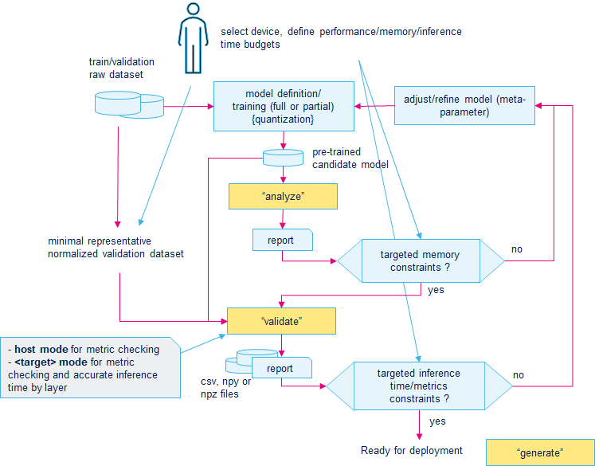

- Checking of the budgeted memory (ROM/RAM) can be done in the inner loop (topology selection/definition) before the time-consuming training process (or retraining process) to preconstraint the choices of the neural network architecture according to the memory budgets.
- Note that the “analyze” and “host validate” step can be merged, “analyze” information are also available in the “validate” reports.

## Error handling

During the execution of a given command, after the parsing of the arguments if an error is raised, the `stedgeai` application returns `-1` (else `0` is returned).

A category and a short description prefix an error message.

| category | description |
| --- | --- |
| CLI ERROR | specific CLI error |
| LOAD ERROR | error during the load/import of the model or the connection with the board - OSError, IOError |
| NOT IMPLEMENTED | expected feature is not implemented - NotImplementedError |
| INTERRUPT | indicates that the execution of the command has been interrupted (`CTRL-C` or kill system signal) - KeyboardInterrupt, SystemExit |
| TOOLS ERROR, INTERNAL ERROR | internal error - ImportError, RuntimeError, ValueError |

Note

There is a specific attention to have explicit and relevant short description of the error messages. Unfortunately, this is not always the case, do not hesitate to contact the local support or to use the product [ST Community channel/forum, *“Edge AI”*](https://community.st.com/t5/edge-ai/bd-p/edge-ai).

**Example of specific error**

```powershell
$ stedgeai validate model.tflite --target ispu -t keras
...
E102(CliArgumentError): Wrong model files for 'keras'
```

# Analyze command

- stm32xx (including the stm32n6 series w/o NPU)
- sr5[xx]
- sr6p[xx]
- sr6g[xx]
- ispu
- mlc (see specific article)

## Description

The `'analyze'` command is the primary command to import, parse, and check an uploaded pretrained model. A detailed report provides the main metrics to know if the generated code can be deployed on the targeted device. It also includes the rendering information by layer or/and operator (see “C-graph description” section). It provides the size of the requested RT memory size to store the kernel and specific network binary objects. After completion, the user can be fully *confident* in the imported model in term of supported layers/operators.

[figure not shown]

## Examples

- Analyze a model

  ```bash
  $ stedgeai analyze -m <model_file_path> --target <target>
  ```

- Analyze Keras model saved in two separated files: model.json + model.hdf5

  ```bash
  $ stedgeai analyze -m <model_file_path>.json -m <model_file_path>.hdf5 --target <target>
  ```

- Analyze a 32b float model with compression request

  ```bash
  $ stedgeai analyze -m <model_file_path> -c low --target <target>
  ```

- Analyze a model with the input tensors placed in the activations buffer

  ```bash
  $ stedgeai analyze -m <model_file_path> --allocate-inputs --target <target>
  ```

## Common options

This section describes the common options for the analyze, validate, and generate commands. The specific options are described in the respective command section.

### `-m/--model FILE`

Path of the model files (see “Deep Learning (DL) framework detection” section). Note that the same `-m` argument should be also used to indicate the weights file if necessary - *Mandatory*

**Details**

#### Deep Learning (DL) framework detection

Extensions of the model files are used to identify the DL framework which should be used to import the model. If the autodetection is ambiguous, the `'--type/-t'` option should be used to define the correct framework.

| DL framework | type (–type/-t) | file extension |
| --- | --- | --- |
| Keras | `keras` | `.h5` or `.hdf5` and `.json` |
| TensorFlow lite | `tflite` | `.tflite` |
| ONNX | `onnx` | `.onnx` |

### `--target STR`

Indicates the ST targeted device or series. - *Mandatory*

### `-t/--type STR`

Indicates the type of the original deep learning (DL) framework when the extension of the model files does not allow inference (see “DL framework detection” section) - *Optional*

### `-w/--workspace DIR`

Indicates a working or temporary directory for the intermediate or temporary files (default:`"./st_ai_ws/"` directory) - *Optional*

### `-o/--output DIR`

Indicates the output directory for the generated C files and report files (default:`"./st_ai_output/"`directory) - *Optional*

### `-n/--name STR`

Indicates the C-name (*C-string* type) for the imported model. This name is used to prefix the names of specialized neural network (NN) C-files and API functions. It is also used for temporary files, allowing the use of the same workspace and output directories for different models (default: `"network"`). - *Optional*

### `-c/--compression STR`

- supported target: `stm32xx`, `sr5[xx]`, `sr6p[xx]`, `sr6g[xx]`
- unsupported target: `stm32n6` with NPU, `mlc`, `ispu`

Indicates the expected compression level applied on the different operators. Supported values: `none|lossless|low|medium|high` (Default: `lossless`) to apply the same level for all operators, or a simple `json` file to define a compression level by operator. - *Optional*

**Details**

During the optimization passes of the imported model, different compression level can be applied. Underlying applied compression algorithms depend on the selected level and the configuration of the operator/layer itself.

| level | description |
| --- | --- |
| `none` | no compression |
| `lossless` | applied algorithms ensuring the accuracy (structural compression) |
| `low` | applied algorithms trying to reduce the size of the parameters with a minimum of accuracy loss |
| `medium` | more aggressive algorithms, the final accuracy loss can be more important |
| `high` | extreme aggressive algorithms (not used) |

#### Supported compressions by operator

- **Floating-point dense or fully connected layers**: `'low/medium/high'` enables the compression of weights or/and bias. With `'low'`, a targeted compression factor of `'4'` is applied while with `'medium\high' the targeted compression factor is`‘8’`.
- **ONNX-ML TreeEnsembleClassifier operator**: With `'none'` level, no compression or optimization is applied. `'lossless'` enables a first level of compression w/o loss of accuracy. `'low','medium','high'` enable compression weights.

Warning

Only **float32** (or float) are supported by the code generator, this implies that during the import of the operator, the **float64** (or double) values are converted in float32.

#### Specify a compression level by operator

By default, the compression process tries to apply globally the same compression level for all eligible operators. If the global accuracy is too much impacted or to *force* the compression, the user has the possibility to refine the expected compression level layer-by-layer.

A JSON file must be defined to indicate what is the compression level which must be applied for a given layer. The original name specifies the name of the layer.

```json
{
    "layers": {
        "dense_2": {"factor": "high"},
    }
}
```

The option `-c/--compression` can be used to pass the configuration file.

```
$ stedgeai analyze -m <model_file> --target stm32 -c <conf_file>.json
```

Note

Be aware that a specific layer could not be compressed if the gain of weight size is not enough.

### `--no-inputs-allocation`

- supported target: `stm32xx`,`stm32n6` with NPU, `sr5[xx]`, `sr6p[xx]`, `sr6g[xx]`, `ispu`
- unsupported target: `mlc`

If defined, this flag indicates that **no** space is reserved in the activations buffer to store the input buffers. The application must allocate them separately in the user memory space and provide them to the execution engine before performing the inference. Refer to the *“IO buffers into activations buffer”* section. - *Optional*

### `--no-outputs-allocation`

- supported target: `stm32xx`,`stm32n6` with NPU, `sr5[xx]`, `sr6p[xx]`, `sr6g[xx]`, `ispu`
- unsupported target: `mlc`

If defined, this flag indicates that **no** space is reserved in the activations buffer to store the ouput buffers. The application must allocate them separately in the user memory space and provide them to the execution engine before performing the inference. Refer to the *“IO buffers into activations buffer”* section. - *Optional*

### `--input-memory-alignment INT`

- supported target: `stm32xx`, `sr5[xx]`, `sr6p[xx]`, `sr6g[xx]`, `ispu`
- unsupported target: `stm32n6` with NPU, `mlc`

If defined, set the memory-alignment constraint in bytes (multiple of 2) to allocate the input buffer inside the “activations” buffer. By default 4 (or 8 bytes dependent of system bus-width) are used. Refer to the *“I/O buffers into activations buffer”* section. - *Optional*

### `--output-memory-alignment INT`

- supported target: `stm32xx`, `sr5[xx]`, `sr6p[xx]`, `sr6g[xx]`, `ispu`
- unsupported target: `stm32n6` with NPU, `mlc`

If defined, set the memory-alignment constraint in bytes (multiple of 2) to allocate the output buffer inside the “activations” buffer. By default 4 (or 8 bytes dependent of system bus-width) are used. Refer to *“I/O buffers into activations buffer”* section. - *Optional*

### `--memory-pool FILE`

- supported target: `stm32xx`, `sr5[xx]`, `sr6p[xx]`, `sr6g[xx]`
- unsupported target: `stm32n6` with NPU, `mlc`, `ispu`

Indicate the file path of the memory pool descriptor file. It allows to describe the memory regions allowing to support the multiheap use-case.- *Optional*

**Details**

#### Description of the Memory pools

For advanced use-cases, the user has the possibility to pass (through the `'--memory-pool'` option), a text file (JSON file format) allowing to specify some properties of the targeted device. The **“1.0”** JSON version allows only to provide the descriptions of the memory pools.

```json
{
    "version": "1.0",
    "memory": {
        "mempools": [
            {
                "name": "sram",
                "size": "128KB",
                "usable_size": "96KB"
            }
        ]
    }
}
```

| key | description |
| --- | --- |
| `"version"` | version/format of the JSON file. Only `"1.0"` value is supported - *mandatory* |
| `"memory"` | key to describe the memory properties (dict) - *optional* |
| `"mempools"` | key to describe the memory pool (list of dict) - *optional* |

Memory pool description (`"mempools"` item)

| key | description |
| --- | --- |
| `"name"` | user name, if not defined a generic name is generated: `pool_{pos}` - *optional* |
| `"size"` | indicate the total size - *mandatory* |
| `"usable_size"` | indicate the maximum size which can be used - if not defined, `size` is used - *optional* |
| `"address"` | indicate the base @ of memory pool (ex. `0x2000000`) - *optional* |

- value is defined as a string, `"B,KB,MB"` can be used to indicate the size. `"0x"` prefix indicates value in hexadecimal.
- no target device database is embedded in the CLI to check that the provided memory pool descriptors are valid.
- Note that if `"address"` attribute is defined and if the associated memory pool is used, the value is used as-is to define the default address of the activations buffer by the generated code (see generated `<network>_data.c` file).

A typical example of JSON file indicates that two budgeted memory pools can be used to place the activations buffer. `"dtcm"` memory pool is privileged to place the critical buffers.

```
{
    "version": "1.0",
    "memory": {
        "mempools": [
            {
                "name": "dtcm",
                "size": "128KB",
                "usable_size": "64KB"
            },
            {
                "name": "ram_d1",
                "size": "512KB",
                "usable_size": "256KB"
            },
            {
                "name": "default"
            }
        ]
    }
}
```

### `--fix-parametric-shapes`

- supported target: `stm32xx`,`stm32n6` with NPU, `sr5[xx]`, `sr6p[xx]`, `sr6g[xx]`, `ispu`
- unsupported target: `mlc`

Set parametric dimensions in the shapes of the input tensors (default: parametric dimensions are set to 1) - *Optional*

**Details**

Accepted formats are

| format | description |
| --- | --- |
| List of tuples | A list of tuples specifying for each input tensor its input shape. The tensors order is the same shown by Netron. Example: `[(1,2,3),(1,3,4)]` |
| Dictionary (tensors) | A dictionary which associates an input tensor name with its value. Example: `{'input1':(1,5,6),'input0':(1,4,5)}` |
| Dictionary (dimensions) | A dictionary which associates a dimension name with its value. Example: `{'batch_size':1,'sequence_length':10,'sample_size':12}` |

### `--split-weights`

- supported target: `stm32xx`, `sr5[xx]`, `sr6p[xx]`, `sr6g[xx]`, `ispu`
- unsupported target: `stm32n6` with NPU, `mlc`

If defined, this flag indicates that one c-array is generated per weights/bias data tensor instead to have a unique C-array (“weights” buffer) for the whole model (default: disabled), (refer to *“Split weights buffer”* section) - *Optional*

### `-O/--optimization STR`

- supported target: `stm32xx`, `sr5[xx]`, `sr6p[xx]`, `sr6g[xx]`
- unsupported target: `stm32n6` with NPU, `mlc`, `ispu`

Indicate the `objective` of the applied optimization passes - *Optional*

**Details**

#### Optimization objectives

The `'-O/--optimization'` option is used to indicate the objective of the optimization passes which are applied to deploy the c-model. Note that the accuracy/precision of the generated model is not impacted. By default (w/o option), a trade-off (that is, `balanced`) is considered.

| objective | description |
| --- | --- |
| `time` | apply the optimization passes to reduce the inference time (or latency). In this case, the size of the used RAM (activations buffer) can be impacted. |
| `ram` | apply the optimization passes to reduce the RAM used for the activations. In this case, the inference time can be impacted. |
| `balanced` | trade-off between the `'time'` and the `'ram'` objectives. Reduces RAM usage yet minimizing impact on inference time |

The following figure illustrates the usage of the optimization option. It is based on the `'Nucleo-H743ZI@480MHz'` board with the small MLPerf Tiny quantized models from https://github.com/mlcommons/tiny/tree/master/benchmark/training.

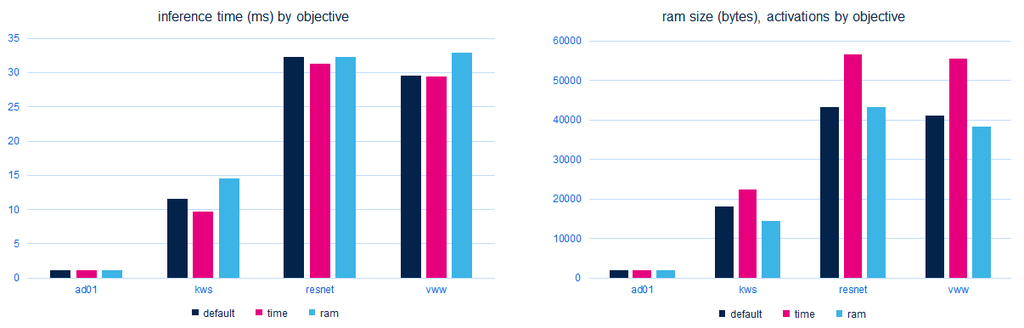

### `--c-api STR`

- supported target: `stm32xx`, `sr5[xx]`, `sr6p[xx]`, `sr6g[xx]` (for `ispu` only `st-ai` is supported)
- unsupported target: `stm32n6` with NPU, `mlc`

Select the generated embedded inference C-API: '`legacy`' or '`st-ai`'. The default is '`st-ai`' for all supported targets. For more details, refer to the *“Embedded Inference Client API”* and *“Embedded Inference Client ST Edge AI API”* articles - *Optional*

### `--allocate-activations`

- supported target: `stm32xx`, `sr5[xx]`, `sr6p[xx]`, `sr6g[xx]`, `ispu`
- unsupported target: `stm32n6` with NPU, `mlc`

(Experimental) Supported only with the `st-ai` c-api, this option indicates that the runtime space must allocate the memory buffers to store the activations. Otherwise, the application must provide them (default behavior) - *Optional*

### `--allocate-states`

- supported target: `stm32xx`, `sr5[xx]`, `sr6p[xx]`, `sr6g[xx]`, `ispu`
- unsupported target: `stm32n6` with NPU, `mlc`

(Experimental) Supported only with the `st-ai` c-api, this option indicates that the runtime space must allocate the memory buffers to store the states. Otherwise, the application must provide them (default behavior) - *Optional*

### `--input-data-type`

- supported target: `stm32xx`,`stm32n6` with NPU, `sr5[xx]`, `sr6p[xx]`, `sr6g[xx]`, `ispu`
- unsupported target: `mlc`

For the quantized models, indicates the expected inputs data type of generated implementation. Multiple inputs definition is supported: in_data_type_1,in_data_type_2,… If one data type is given, it will be applied for all inputs (possible values: float32|int8|uint8) - *Optional*

**Details**

| model type | supported options |
| --- | --- |
| Keras (float) | `int8` and `uint8` data type are not supported. `float32` can be used but the original data type is unchanged. |
| ONNX (float) | `int8` and `uint8` data type are not supported. `float32` can be used but the original data type is unchanged. |
| TFlite (float) | `int8` and `uint8` data type are not supported. `float32` can be used but the original data type is unchanged. |
| TFlite (quantized) | `int8`, `uint8` and `float32` are supported. According the original data types a converter is inserted. |
| ONNX (quantized)* | `int8`, `uint8` and `float32` are supported. According the original data types a converter is inserted. |

(*) by default for this type of model, the original I/O data type (float32) is converted to int8 data type to feed directly the int8 kernels allowing to support efficiently the deployed ONNX QDQ models (see *“QDQ format deployment”* section).

### `--output-data-type`

- supported target: `stm32xx`,`stm32n6` with NPU, `sr5[xx]`, `sr6p[xx]`, `sr6g[xx]`, `ispu`
- unsupported target: `mlc`

For the quantized models, indicates the expected outputs data type of generated implementation. Multiple outputs definition is supported: out_data_type_1,out_data_type_2,… If one data type is given, it is applied for all outputs (possible values: float32|int8|uint8) - *Optional*

### `--cut-input-tensors`

For the TFlite models should be specified a single tensor location or a comma separated list of tensors locations by which to cut the input model. For the ONNX models should be specified a single tensor name or a comma separated list of tensors names by which to cut the input model.

### `--cut-output-tensors`

For the TFlite models should be specified a single tensor location or a comma separated list of tensors locations by which to cut the input model. For the ONNX models should be specified a single tensor name or a comma separated list of tensors names by which to cut the input model.

### `--cut-input-layers`

For the TFlite models should be specified a single layer location or a comma separated list of layers locations by which to cut the input model. For the Keras models should be specified a single layer index or a comma separated list of layers indexes by which to cut the input model.

### `--cut-output-layers`

For the TFlite models should be specified a single layer location or a comma separated list of layers locations by which to cut the input model. For the Keras models should be specified a single layer index or a comma separated list of layers indexes by which to cut the input model.

### `--inputs-ch-position`

- supported target: `stm32xx`,`stm32n6` with NPU, `sr5[xx]`, `sr6p[xx]`, `sr6g[xx]`, `ispu`
- unsupported target: `mlc`

Indicate the expected NCHW (channel first) or NHWC (channel last) data layout for the inputs (refer to *“How to change the I/O data type or layout (NHWC vs NCHW)”* article for more details). Note that this option is applied for all inputs if multiple inputs - possible values: chfirst|chlast - *Optional*

### `--outputs-ch-position`

- supported target: `stm32xx`,`stm32n6` with NPU, `sr5[xx]`, `sr6p[xx]`, `sr6g[xx]`, `ispu`
- unsupported target: `mlc`

Indicate the expected NCHW (channel first) or NHWC (channel last) data layout for the outputs (refer to *“How to change the I/O data type or layout (NHWC vs NCHW)”* article for more details). Note that this option is applied for all outputs if multiple outputs - possible values: chfirst|chlast - *Optional*

### `--no-onnx-optimizer`

- supported target: `stm32xx`,`stm32n6` with NPU, `sr5[xx]`, `sr6p[xx]`, `sr6g[xx]`, `ispu`
- unsupported target: `mlc`

Disable the ONNX optimizer pass before to import the ONNX model - *Optional*

### `--use-onnx-simplifier`

- supported target: `stm32xx`, `stm32n6` with NPU , `sr5[xx]`, `sr6p[xx]`, `sr6g[xx]`, `ispu`
- unsupported target: `mlc`

Enable the ONNX simplifier pass before to import the ONNX model (default: False) - *Optional*

### `--st-neural-art STR`

- supported target: stm32n6 with ST Neural-ART NPU
- unsupported target: `stm32xx`, `sr5[xx]`, `sr6p[xx]`, `sr6g[xx]`, `ispu`, `mlc`

Set the selected profile (including the ST Neural-ART compiler options, refer to *“ST Neural ART compiler primer”* article) from a well-defined configuration file.

### `--custom FILE`

- supported target: `stm32xx`,`stm32n6` with NPU, `sr5[xx]`, `sr6p[xx]`, `sr6g[xx]`, `ispu`
- unsupported target: `mlc`

Path of the configuration file (JSON file) to support the custom layers (refer to *“Keras Lambda/custom layer support”* article) - *Optional*

### `--quiet`

Disable the display of the progress bar during the execution of the command - *Optional*

## Out-of-the-box information

The first part of the log shows the used arguments and the main metrics of the C implementation.

```
$ stedgeai analyze -m ds_cnn.h5 --target stm32
..
 Exec/report summary (analyze)
 -------------------------------------------------------------------------------------------
 model file         :   <model-path>\ds_cnn.h5
 type               :   keras
 c_name             :   network
 compression        :   lossless
 optimization       :   balanced
 target/series      :   stm32h7
 workspace dir      :   <workspace-directory-path>
 output dir         :   <output-directory-path>
 model_fmt          :   float
 model_name         :   ds_cnn
 model_hash         :   0xb773f449281f9d970d5b982fb57db61f
 params #           :   40,140 items (156.80 KiB)
 -------------------------------------------------------------------------------------------
 input 1/1          :   'input_0', f32(1x49x10x1), 1.91 KBytes, user
 output 1/1         :   'dense_1', f32(1x12), 48 Bytes, user
 macc               :   4,833,792
 weights (ro)       :   158,768 B (155.05 KiB) (1 segment) / -1,792(-1.1%) vs float model
 activations (rw)   :   55,552 B (54.25 KiB) (1 segment)
 ram (total)        :   57,560 B (56.21 KiB) = 55,552 + 1,960 + 48
 -------------------------------------------------------------------------------------------
...
```

The initial subsection recalls the CLI arguments. Note that the full raw command line is saved at the beginning of the generated report file: `<output-directory-path>\network_<cmd>_report.txt`

| field | description |
| --- | --- |
| model file | reports the full-path of the original model files (`-m/--model`). If multiple files, there is one line by file. |
| type | reports the `-t/--type` value or inferred DL framework type |
| c_name | reports the expected C-name for the generated C-model (`-n/--name`) |
| compression | reports the applied compression level (`-c/--compression`) |
| optimization | reports the selected objective: `balanced` (default), `ram` or `time`, (`-O/--optimization`) |
| target/series | reports the selected target/series (`--target`) |
| workspace dir | full-path of the workspace directory (`-w/--workspace`) |
| output dir | full-path of the output directory (`-o/--output`) |

The second part shows the results of the importing and rendering stages.

| field | description |
| --- | --- |
| model_fmt | designates the main format of the generated model: `float`, `ss/sa`, `dqnn`,.. |
| model_name | designates the name of the provided model. This is generally the name of the model file. |
| model_hash | provides the computed MD5 signature of the imported model files. |
| input | indicates the name, the format, the shape, and the size in bytes of an input tensor. There is one line by input. `'inputs (total)'` field indicates the total size (in bytes) of the inputs. |
| output | indicates the name, the format, the shape, and the size of the output tensor. There is one line by output. `outputs (total)` field indicates the total size (in bytes) of the outputs. |
| params # | indicates the total number of parameters of the original model and its associated size in bytes. |
| macc | indicates the whole computational complexity of the original model. Value is defined in `MACC` operations: Multiply ACCumulated operations, refer to *“Computational complexity: MACC and cycles/MACC”* |
| weights (ro) | indicates the requested size (in bytes) for the generated constant RO parameters (weights and bias tensors). The size is 4 bytes aligned. If the value is different from the original model files, the r… |
| activations (rw) | indicates the requested size (in bytes) for the working RW memory buffer (also called activations buffer). It is mainly used as an *internal heap* for the activations and temporary results. (refer to … |
| ram (total) | indicates the requested total size (in bytes) for the RAM including the input and output buffers. |

Note that when the `--memory-pool` is passed, the next part `'Memory-pools summary'` summarizes the usage of the memory pools.

```
  Memory-pools summary (activations/ domain)
  --------------------------- ---- -------------------------- ---------
  name                        id   used                       buffer#
  --------------------------- ---- -------------------------- ---------
  sram                        0    54.25 KiB (10.8%)          34
  weights_array               1    155.05 KiB (15876800.0%)   35
  input_0_output_array_pool   2    1.91 KiB (196000.0%)       1
  dense_1_output_array_pool   3    48 B (4800.0%)             1
  --------------------------- ---- -------------------------- ---------
```

- Example of ‘input/output’ description

  ```
  'input_0', f32(1x49x10x1), 1.91 KBytes, user
  ```

  Indicates that `input_0` tensor has a size of 490 floating-point items (size in bytes = `490 x 4B = 1.91KiB`) with a `(1x49x10x1)` shape, the associated memory chunk will be provided by the application (`'user'` domain) application (refer to *“I/O tensor description”* section). On the contrary in

  ```
  'input_0', f32(1x49x10x1), 1.91 KBytes, activations
  ```

  The description is similar, however thanks the `--allocate-inputs` option, a specific region is reserved in the activations buffer for the input (`'activations'` domain).
- Compressed floating-point model example

  For a *“compressed”* floating-point model, the compression gain for the `'weights'` size, here *-72.90%* is the global difference between a 32b float model and the generated *“compressed”* C-model. *Note that only the full-connected or dense layers can be compressed.*

  ```
  $ stedgeai analyze -m dnn.h5 -c low --target stm32
  ...
  compression        :   low
  ...
  input 1/1          :   'input_0', f32(1x490), 1.91 KBytes, user
  output 1/1         :   'dense_4', f32(1x12), 48 Bytes, user
  macc               :   114,816
  weights (ro)       :   123,792 B (120.89 KiB) (1 segment) / -333,024(-72.9%) vs float model
  activations (rw)   :   1,152 B (1.12 KiB) (1 segment)
  ram (total)        :   3,160 B (3.09 KiB) = 1,152 + 1,960 + 48
  ...
  ```

- Quantized TFLite model example - integer format

  The following report shows the case where a TensorFlow lite quantized model is imported and the inputs are placed in the activations buffer. Note that for each input (or output), type/scale, and zero-point value are reported. Additional infos are displayed in the “IR Graph description” section.

  ```
  $ stedgeai analyze -m <quantized_model_file>.tflite --allocate-inputs --target stm32
  ...
  input 1/1          :   'Reshape_1', int8(1x1960), 1.91 KBytes, QLinear(0.101715684,-128,int8), activations
  output 1/1         :   'nl_3', int8(1x4), 4 Bytes, QLinear(0.003906250,-128,int8), user
  macc               :   336,072
  weights (ro)       :   16,688 B (16.30 KiB) (1 segment) / -49,920(-74.9%) vs float model
  activations (rw)   :   12,004 B (11.72 KiB) (1 segment) *
  ram (total)        :   12,008 B (11.73 KiB) = 12,004 + 0 + 4

  (*) input buffers can be used from the activations buffer
  ...
  ```

## IR graph description

The outlined “graph” section (table form) provides a summary of the topology of the network which is considered before the optimization, render, and generation stages. The `'id'` column indicates the index of the operator from the original graph. It is generated by the importer. The described graph is an internal platform-independent representation (or IR) created during the import of the model. Only training operators are ignored. Note that if no input operator is defined, an “input” layer is added and the nonlinearity functions are unfused.

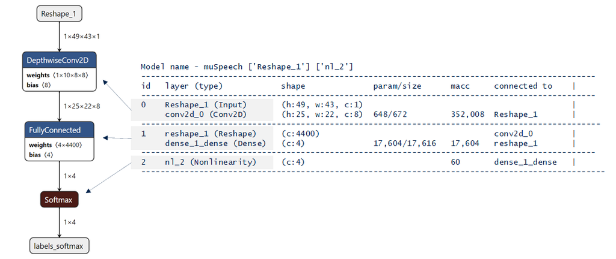

| field | description |
| --- | --- |
| id | indicates the layer/operator index in the original model. |
| layer (type) | designates the name and type of the operator. The name is inferred from the original name. In the case where a nonlinearity function is unfused, the new IR-node is created with the original name suffi… |
| shape | indicates the output shape of the layer. Follow the “HWC” layout or channel last representation (refer to *“I/O tensor”* section) |
| param/size | indicates the number of parameters and their sizes in bytes (4 bytes aligned) |
| macc | designates the complexity in multiply-accumulated operations, refer to *“Computational complexity: MACC and cycles/MACC”* |
| connected to | designates the name of the incoming operators/layers |

The right side of the table (`'c_*'` columns) reports generated C-object after optimization and rendering stages.

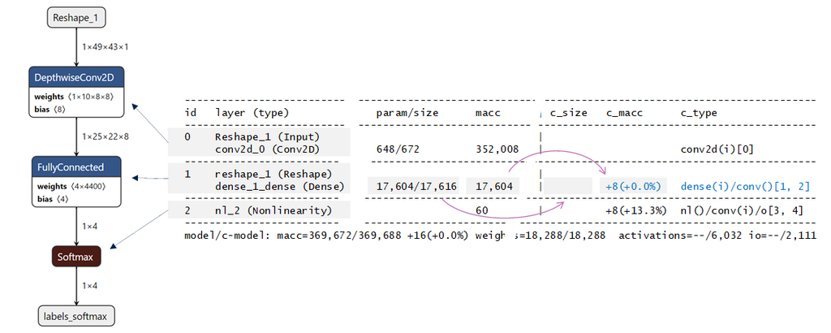

| field | description |
| --- | --- |
| c_size | indicates the difference in bytes of the size for the implemented weights/params tensors. If nothing is indicated, the size is unchanged compared to the original size (`'-/size'` field) |
| c_macc | indicates the difference in MACC. If nothing is displayed, the final complexity of the C-operator is comparable to the complexity of the original layer/operator (`'macc'` field). |
| c_type | indicates the type of the c-operator. The value between square is the index in the c-graph. The value between parenthesis is the data type: `'()'` indicates a float32 type, `'(i)'` for integer type, `… |

Footer summarizes the differences for the whole model including the requested RAM size for the activations buffer and for the I/O tensors.

```powershell
model/c-model: macc=369,672/369,688 +16(+0.0%) weights=18,288/18,288
           activations=--/6,032 io=--/2,111
```

In the case where the optimizer engine has folded or/and fused the IR nodes, the `'c_type'` is empty.

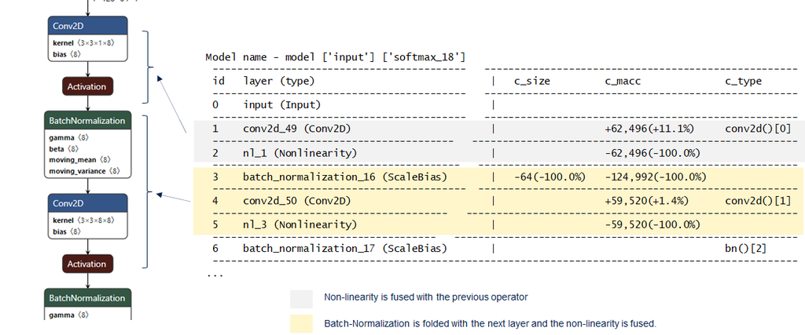

The following figure is an example of an IR graph with a residual neural network. As for the multiple branches, no specific information is added, `'connected to'` column allows to know the connections.

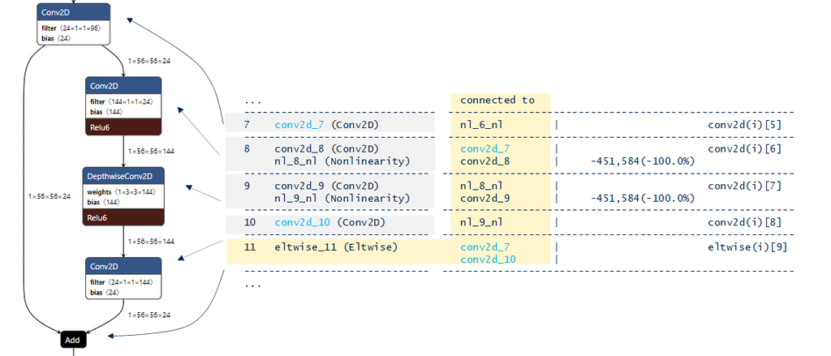

Warning

For a compressed or quantized model, the MACC values (by layer or globally) are unchanged since the number of operations is always the same. Only the associated number of CPU cycles by MACC is changed. In particular, for the quantized models.

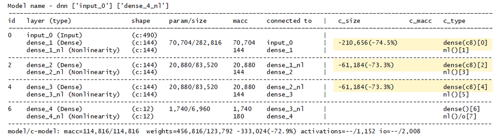

## Number of operations per c-layer

Number of operations by generated C-layer (`'c_id'`) according to the type of data is provided. With the synthesis by types of operations for the entire model, this information makes it possible to know the partitioning of the operations in relation with the types of data.

```
 Number of operations per c-layer
 ----------------------------------------------------------------------------------------------
 c_id    m_id   name (type)                                     #op (type)
 ----------------------------------------------------------------------------------------------
 0       1      quant_conv2d_conv2d (conv2d_dqnn)                       230,416 (smul_s8_s8)
 1       3      quant_conv2d_1_conv2d (conv2d_dqnn)                   1,843,200 (sxor_s1_s1)
 ...
 14      25     quant_depthwise_conv2d_3_conv2d (conv2d_dqnn)            28,800 (sxor_s1_s1)
 ...
 16      28     quant_conv2d_7_conv2d (conv2d_dqnn)                   1,638,400 (sxor_s1_s1)
 17      30     activation (nl)                                           6,400 (op_f32_f32)
 18      32     conv2d_conv2d (conv2d)                                   76,812 (smul_f32_f32)
 ----------------------------------------------------------------------------------------------
 total                                                               10,067,228

   Number of operation types
   ---------------------------------------------
   smul_s8_s8               230,416        2.3%
   sxor_s1_s1             9,740,800       96.8%
   op_s1_s1                  12,800        0.1%
   op_f32_f32                 6,400        0.1%
   smul_f32_f32              76,812        0.8%
```

| operation | description |
| --- | --- |
| `smul_f32_f32` | floating-point macc-type operation |
| `smul_s8_s8` | 8-bit signed integer macc-type operation |
| `op_f32_f32` | Floating point operation (nonlinearity, elemtwise op…) |
| `conv_s8_f32` | converter operation; s8 -> f32 |
| `xor_s1_s1` | binary operation (~macc) |

## Complexity report per layer

The last part of the report summarizes the relative network complexity in term of MACC and associated ROM size by layer. Note that only the operators which contribute to the global `'c_macc'` and `'c_rom'` metrics are reported. `'c_id'` indicates the index of the associated c-node.

```
 Complexity report per layer - macc=18,752,688 weights=7,552 act=3,097,600 ram_io=602,184
 ---------------------------------------------------------------------------------------------------
 id   name                             c_macc                    c_rom                     c_id
 ---------------------------------------------------------------------------------------------------
 1    separable_conv1                  ||                 1.8%   ||                 1.6%   [0]
 1    separable_conv1_conv2d           |||                3.2%   ||||               3.4%   [1]
 2    depthwise_conv2d_1               |||||||||         10.3%   ||||||||           8.5%   [2]
 3    conv2d_1                         ||||||||||||||||  17.6%   ||||||||||||||    14.4%   [3]
 5    dw_conv_branch1                  ||||||||           9.3%   ||||||||           8.5%   [7]
 6    pw_branch1                       ||||||||||||||||  17.6%   ||||||||||||||    14.4%   [8]
 7    dw_conv_branch0                  ||||||||           9.3%   ||||||||           8.5%   [6]
 8    batch_normalization_1            ||                 2.1%   ||                 1.7%   [9]
 9    separable_conv1_branch2          ||||||||           9.3%   ||||||||           8.5%   [4]
 9    separable_conv1_branch2_conv2d   |||||||||||||||   16.5%   ||||||||||||||    14.4%   [5]
 10   add_1                            ||                 2.1%   |                  0.0%   [10, 11]
 11   global_average_pooling2d_1       |                  1.0%   |                  0.0%   [12]
 12   dense_1                          |                  0.0%   ||||||||||||||||  16.2%   [13]
 12   dense_1_nl                       |                  0.0%   |                  0.0%   [14]
```

## C-graph description

Additional “Generated C-graph summary” section is included in the report (also displayed with `'-v 2'` argument). It summarizes the main computational and associated elements (c-objects) used by the C-inference engine (runtime library). It is based on the c-structures generated inside the `'<name>.c'` file. A complete graphic representation is available through the UI (refer to [[UM]](https://www.st.com/resource/en/user_manual/dm00570145.pdf)).

The first part recalls the main structural elements: c-name, number of c-nodes, number of C-array for the data storage of the associated tensors. Input and output name of the I/O tensors.

```
Generated C-graph summary
---------------------------------------------------------------------------------------------------
model name         : microspeech_01
c-name             : network
c-node #           : 5
c-array #          : 11
activations size   : 4352
weights size       : 16688
macc               : 336084
inputs             : ['Reshape_1_output_array']
outputs            : ['nl_2_fmt_output_array']
```

As illustrated in the following figure, the implemented c-graph (*legacy API*) can be considered as a sequential graph, managed as a simple linked list. Fixed-executing order is defined by the C-code optimizer according to two main criteria: data-path dependencies (or tensor dependencies) and the minimization of the RAM memory peak usage.

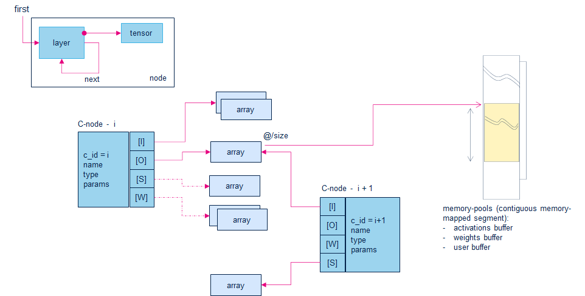

Each computational c-node is entirely defined by:

- operation type, parameters
- input tensors list: [I]
- *optional* weights/bias tensors list: [W]
- *optional* scratches tensors list: [S]
- outputs tensors list: [O]

#### C-Arrays table

`'C-Arrays'` table lists the objects allowing to handle the base address, size, and metadata of the data memory segments for the different tensors. For each item, number of items, size in byte (`'item/size'`), memory segment location (`'mem-pool'`), type (`'c-type'`) and short format description (`'fmt'`) are reported.

```
C-Arrays (11)
---------------------------------------------------------------------------------------------------
c_id  name (*_array)      item/size           mem-pool     c-type         fmt         comment
---------------------------------------------------------------------------------------------------
0     conv2d_0_scratch0   352/352             activations  uint8_t        ua8
1     dense_1_bias        4/16                weights      const int32_t  ss32
2     dense_1_weights     16000/16000         weights      const uint8_t  ua8
3     conv2d_0_bias       8/32                weights      const int32_t  ss32
4     conv2d_0_weights    640/640             weights      const uint8_t  ua8
5     Reshape_1_output    1960/1960           user         uint8_t        ua8         /input
6     conv2d_0_output     4000/4000           activations  uint8_t        ua8
7     dense_1_output      4/4                 activations  uint8_t        ua8
8     dense_1_fmt_output  4/16                activations  float          float
9     nl_2_output         4/16                activations  float          float
10    nl_2_fmt_output     4/4                 user         uint8_t        ua8         /output
---------------------------------------------------------------------------------------------------
```

| mem_pool | description |
| --- | --- |
| activations | part of the activations buffer |
| weights | part of a *ROM* segment |
| user | part of a memory segment owned by the user (client application level) |

| fmt | format description |
| --- | --- |
| float | 32b float numbers |
| s1/packed | binary format |
| bool | boolean format |
| c4/c8 | compressed 32b float numbers. The size includes the dictionary. |
| s, u, ua, ss, sa | integer or/and quantized format (refer to [*“Quantized models support”*]]STAI_CORE_QUANT article). `'/ch(n)'` indicates that per-channel scheme is used (else per-tensor). |